# Re-analysis of CC G2F1 to study crossover interference

Andrew P Morgan

15 April 2025

# Motivation

Crossover interference influences the recombination landscape in many taxa. The strength of interference is modulated by genetic background, sex and other factors. We have previously shown that interference varies with genotype and age in male mice (Morgan & Payseur (2024) *Genetics* 10.1093/genetics/iyae146). Although we showed that a model of interference that accounts for non-interferening crossovers (“interference escape”) fit the data better than a model of interference without escape, we were not able to reliably estimate the proportion of non-interfering crossovers. Our study was also limited to male meiosis. Here we extend the MCMC framework developed in our previous work to study interference in an 8-way outcross including both male and female meioses, accounting for interference escape.

# Experimental design

The Collaborative Cross is a panel of recombinant inbred lines (RIL) created from 8-way intercrosses between mouse strains A/J (A), C57BL6/J (B), 129/SvImJ (C), NOD/ShiLtJ (D), NZO/HlLtJ (E), CAST/EiJ (F), PWK/PhJ (G) and WSB/EiJ (H). We refer to the initial generations of breeding as a “funnel.” Each funnel is uniquely defined by a permutation of the 8 founder strains (for example, “BFGDEAHC”), as shown below. The G2:F1 offspring are a mosaic of the 8 founder strains. There are 8 meioses in the first 2 outcrossing generations of the funnel (denoted G1 and G2), of which 4 occur in females and 4 in males. Because each founder strain enters the funnel exactly once, each haplotype junction observed in the G2:F1 offspring represents a crossover that can be assigned uniquely to one of these 8 meioses. Crossovers in G2, if they are transmitted, are observed with probability $1$; crossovers in G1 can only be observed if they are transmitted again through at least one G2 meiosis, and thus are observed with probability $\frac{3}{4}$. (Note that since the G1 and G2 meioses are mechanistically independent, the observed G1 crossovers are a random sample of all G1 crossovers.) By genotyping and reconstructing the haplotype mosaic for a pair of G2:F1 offspring we thus recover at least partial information about 8 meioses.

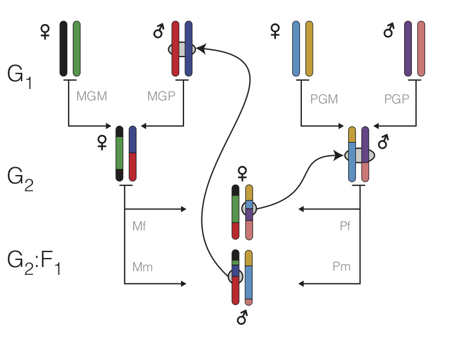

Collaborative Cross breeding design.

# Overview of the dataset

The initial analysis of the CC G2:F1 population reported a total of $2.1993\times 10^{4}$ distinct crossovers (of which $2.1368\times 10^{4}$ were on the autosomes) and used them to construct sex-specific genetic maps. We will load both the table of crossovers and the genetic maps and confirm that the numbers match expectations.

```r
funnels <- read_csv("old_data/funnels.csv") %>%
    select(funnel, order) %>%
    unique()
meioses <- readRDS("xos_inferred/meioses.rds")
xos <- readRDS("xos_inferred/xo_detail_all.rds")
sex_maps <- readRDS("xos_inferred/chrlen.rds")

m2s <- c("Mf" = "F", "Mm" = "F", "MGM" = "F", "PGM" = "F",
         "Pf" = "M", "Pm" = "M", "MGP" = "M", "PGP" = "M")
m2g <- c("Mf" = "G2", "Mm" = "G2", "MGM" = "G1", "PGM" = "G1",
         "Pf" = "G2", "Pm" = "G2", "MGP" = "G1", "PGP" = "G1")
```

For each crossover event, we have its physical and sex-specific genetic position, flanking haplotypes and the meiosis to which it is assigned. Note that the sex here is the sex of the parent in whose germline the crossover occured, *not* the sex of the G2:F1 offspring in whose genome the crossover was observed.

```r
head(xos) %>%
    select(-order)
```

```
## # A tibble: 6 × 11
## # Groups:   sex, chr [4]
##   funnel meiosis sex   chr      start    end from  to       pos generation    cM
##   <chr>  <chr>   <chr> <fct>    <dbl>  <dbl> <chr> <chr>  <dbl> <chr>      <dbl>
## 1 OR5469 Mf      F     chr2    1.76e7 1.76e7 D     F     1.76e7 G2         12.6
## 2 OR5469 Mf      F     chr2    1.07e8 1.07e8 F     G     1.07e8 G2         56.1
## 3 OR5469 Pf      M     chr2    1.56e8 1.57e8 E     B     1.57e8 G2         58.8
## 4 OR5469 Pf      M     chr3    1.59e7 1.60e7 B     E     1.59e7 G2          1.72
## 5 OR5469 MGM     F     chr3    2.17e7 2.17e7 G     D     2.17e7 G1          7.63
## 6 OR5469 MGM     F     chr3    1.18e8 1.18e8 D     G     1.18e8 G1         54.1
```

Each meiosis can be assigned to a specific point in the pedigree for a specific funnel.

```r
head(meioses)
```

```
## # A tibble: 6 × 5
##   funnel meiosis iid        generation sex
##   <chr>  <chr>   <chr>      <chr>      <chr>
## 1 OR1005 Mf      OR1005_Mf  G2         F
## 2 OR1005 Mm      OR1005_Mm  G2         F
## 3 OR1005 MGM     OR1005_MGM G1         F
## 4 OR1005 PGM     OR1005_PGM G1         F
## 5 OR1005 Pf      OR1005_Pf  G2         M
## 6 OR1005 Pm      OR1005_Pm  G2         M
```

Each funnel is defined by a permutation of founder strains (here abbreviated with 1-letter codes.)

```r
head(funnels)
```

```
## # A tibble: 6 × 2
##   funnel order
##   <chr>  <chr>
## 1 OR1005 EDFHBGAC
## 2 OR1009 GCBFDHEA
## 3 OR1018 HACFDEGB
## 4 OR1048 BAEHGFCD
## 5 OR1057 AHDBFCGE
## 6 OR1109 GEBADCHF
```

Are all crossovers accounted for?

```r
NXO
```

```
## [1] 21993
```

```r
nrow(xos) == NXO
```

```
## [1] TRUE
```

Does breakdown between sex chromosomes and autosomes match original report?

```r
mutate(xos, chrtype = factor_chromtype(chr)) %>%
    group_by(chrtype) %>%
    summarise(n = n())
```

```
## # A tibble: 2 × 2
##   chrtype     n
##   <fct>   <int>
## 1 A       21368
## 2 X         625
```

Are all $237$ funnel identifiers represented, and do these correspond to unique permutations of the founder strains?

```r
length( unique(xos$funnel) ) == 237
```

```
## [1] TRUE
```

```r
length( unique(xos$order) ) == 237
```

```
## [1] TRUE
```

How many autosomal crossovers observed at G1 vs G2? Expected ratio for these is $\frac{3}{4}$.

```r
subset(xos, is_autosome(chr)) %>%
    group_by(generation) %>%
    summarise(n = n()) %>%
    mutate(rel = n/max(n))
```

```
## # A tibble: 2 × 3
##   generation     n   rel
##   <chr>      <int> <dbl>
## 1 G1          9177 0.753
## 2 G2         12191 1
```

How many crossovers per meiosis type? Confirm that no crossovers are recorded from the X chromosome in males. (Note that the pseudoautosomal region was ignored in this project.)

```r
subset(xos) %>%
    mutate(chrtype = factor_chromtype(chr)) %>%
    group_by(generation, meiosis, chrtype) %>%
    summarise(n = n()) %>%
    ungroup() %>%
    pivot_wider(names_from = chrtype, values_from = n)
```

```
## # A tibble: 8 × 4
##   generation meiosis     A     X
##   <chr>      <chr>   <int> <int>
## 1 G1         MGM      2349   118
## 2 G1         MGP      2231    NA
## 3 G1         PGM      2355   174
## 4 G1         PGP      2242    NA
## 5 G2         Mf       3282   183
## 6 G2         Mm       3255   150
## 7 G2         Pf       2871    NA
## 8 G2         Pm       2783    NA
```

Finally, check that the length of the reported autosomal genetic maps matches expectations.

```r
eff_meioses_per_sex <- 1*2*237 + (3/4)*2*237
subset(xos, is_autosome(chr)) %>%
    group_by(sex) %>%
    summarise(n_xos = n(),
              cM_calculated = 100* n_xos / eff_meioses_per_sex,
              cM_reported = sum(sex_maps[[ sex[1] ]][1:19]))
```

```
## # A tibble: 2 × 4
##   sex   n_xos cM_calculated cM_reported
##   <chr> <int>         <dbl>       <dbl>
## 1 F     11241         1355.       1355.
## 2 M     10127         1221.       1221.
```

We conclude that that dataset of crossovers is intact, as reported in the original publication, and that is passes sanity checks.

# Prerequsites for studying crossover interference

For puposes of studying crossover intereference, we require data from whole transmitted chromosomes (hereafter, “meiotic products”); that is, fully phased haplotypes in the offspring For G2 meioses, this is trivial since the meiotic products are the phased haplotypes of the G2:F1 offspring. For G1 meioses, this is more complicated, since the meiotic products are the G2 offspring which were not observed directly. However, G2 genomes can be partially reconstructed from haplotypes transmitted to the G2:F1. The details of this are described in Liu et al (2010) *Bioinformatics* 10.1093/bioinformatics/btq187. Although there is probably useful information to be gained from meiotic products which can be reconstructed for just part of their length, modelling the censoring process seems difficult so we will limit ourselves to meiotic products that can be reconstructed unambiguously over their entire length. We will also limit the analysis to the autosomes.

Load up the table of crossovers inferred in G2 genomes (which represent products of G1 meioses; the notation is confusing). In this table, entries with missing values represent meiotic products which *were* completely observed, but on which there were no crossovers.

```r
g2xos <- readr::read_csv("old_data/g2_unambigious.csv", col_names = c("funnel","meiosis","sex","chr","from","to","pos"))
g2xos$chr <- factor_chrom(g2xos$chr)
g1_obs <- select(g2xos, funnel, meiosis, chr) %>%
    unique() %>%
    subset(is_autosome(chr))
```

Of the ($19$ chromosomes $\times~237$ funnels $\times~4$ meioses) = $1.8012\times 10^{4}$ meiotic products from G2 meioses, all are fully observed. A total of $8221$ G1 meiotic products are fully observed ($45.64\%$ of the total). The number of fully-observed meiotic products per meiosis varies, but distrubution looks approximately normal.

```r
left_join(g1_obs, xos) %>%
    select(funnel, meiosis, chr) %>%
    unique() %>%
    group_by(funnel, meiosis) %>%
    summarise(n_obs = n()) %>%
    with(., stem(n_obs))
```

```
##
##   The decimal point is at the |
##
##    2 | 0
##    3 | 00000
##    4 | 000000000000000000000
##    5 | 000000000000000000000000000000000000000
##    6 | 00000000000000000000000000000000000000000000000000000000000000000000
##    7 | 00000000000000000000000000000000000000000000000000000000000000000000+68
##    8 | 00000000000000000000000000000000000000000000000000000000000000000000+78
##    9 | 00000000000000000000000000000000000000000000000000000000000000000000+91
##   10 | 00000000000000000000000000000000000000000000000000000000000000000000+74
##   11 | 00000000000000000000000000000000000000000000000000000000000000000000+9
##   12 | 000000000000000000000000000000000000000000000000000
##   13 | 0000000000000000000000
##   14 | 00000000000
##   15 | 000
##   16 | 00
```

The key data are genetic distances between crossovers on the same chromosome (pair). Distances from chromosome ends and crosovers are partially informative, as they can be modelled via a censoring process. We construct the table of inter-crossover distances below.

```r
## filter down to just wholly observed chromosomes in G1
xos_g1 <- left_join(g1_obs, xos)
xos_g1$sex <- m2s[ xos_g1$meiosis ]
xos_g1$generation <- m2g[ xos_g1$meiosis ]

## now for G2, add entries for chromosomes transmitted intact (ie no crossover)
## there should be (237 funnels) * 4 G2 meioses * 19 chromosomes = 18012 rows
x <- tidyr::expand_grid( funnel = unique(funnels$funnel),
                         meiosis = c("Mf","Mm","Pf","Pm"),
                         chr = factor_chrom( chromnames(short = FALSE)[1:19] ) )
nrow(x)
```

```
## [1] 18012
```

```r
xos_g2 <- left_join(x, xos)
xos_g2$sex <- m2s[ xos_g2$meiosis ]
xos_g2$generation <- m2g[ xos_g2$meiosis ]
```

(This next chunk is not set to re-run; will load pre-computed values from disk.)

```r
## now, make list of transmitted intervals as is expected for xoi::fitGamma
xodist <- bind_rows( xos_g1, xos_g2 ) %>%
    group_by(funnel, meiosis, sex, generation, chr) %>%
    do( inter_xo_dist(., L = chrlen[[ .$sex[1] ]]) )
xodist$iid <- with(xodist, paste0(funnel, "_", meiosis))
saveRDS(xodist, "xos_inferred/xos_to_ivls.rds")

## now, make list of breakpoints by individual as is expected for xoi::fitStahl
breaks_all <- bind_rows( xos_g1, xos_g2 ) %>%
    mutate(iid = paste0(funnel, "_", meiosis)) %>%
    split(., .$iid) %>%
    lapply(., xo_intervals_to_breaks)
saveRDS(breaks_all, "xos_inferred/breaks_by_iid.rds")
```

```r
xodist <- readRDS("xos_inferred/xos_to_ivls.rds")
breaks_all <- readRDS("xos_inferred/breaks_by_iid.rds")
```

At least ($237$ funnels $\times~4$ G2 meioses) = $948$ meioses should have $19$ fully-observed meiotic products.

```r
sum( sapply(breaks_all, length) >= 19 )
```

```
## [1] 948
```

Show summary of inter-crossover distances, for segments flanked by a pair of crossovers.

```r
subset(xodist, censor == 0) %>%
    group_by(generation, meiosis, sex) %>%
    summarise(min_dist = min(inter),
              median_dist = median(inter),
              mean_dist = mean(inter),
              max_dist = max(inter))
```

```
## # A tibble: 8 × 7
## # Groups:   generation, meiosis [8]
##   generation meiosis sex   min_dist median_dist mean_dist max_dist
##   <chr>      <chr>   <chr>    <dbl>       <dbl>     <dbl>    <dbl>
## 1 G1         MGM     F        12.1         43.4      43.9     79.2
## 2 G1         MGP     M        12.4         44.5      43.3     70.6
## 3 G1         PGM     F        12.4         47.0      47.4     85.4
## 4 G1         PGP     M        15.0         41.9      42.4     78.8
## 5 G2         Mf      F         7.99        44.1      44.6     94.9
## 6 G2         Mm      F        13.5         44.2      44.9    100.
## 7 G2         Pf      M         7.59        45.0      44.2     81.4
## 8 G2         Pm      M        10.2         45.0      44.6     79.1
```

Now show the cumulative distribution of inter-crossover distances by sex and generation.

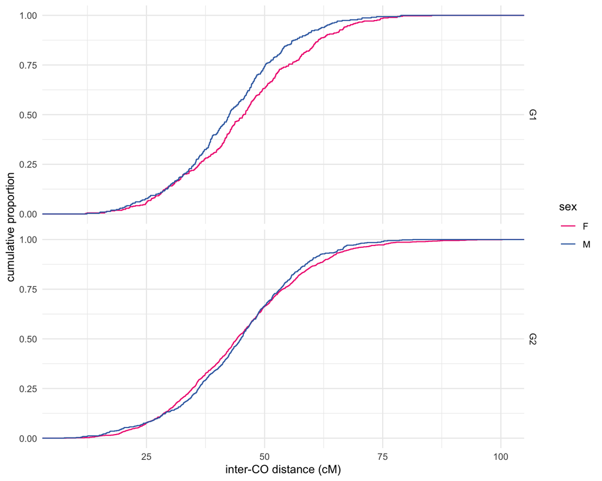

```r
subset(xodist, censor == 0) %>%
    ggplot() +
    stat_ecdf(aes(x = inter, color = sex)) +
    scale_x_continuous("inter-CO distance (cM)") +
    scale_y_continuous("cumulative proportion") +
    scale_color_sex() +
    facet_grid(generation ~ .)
```

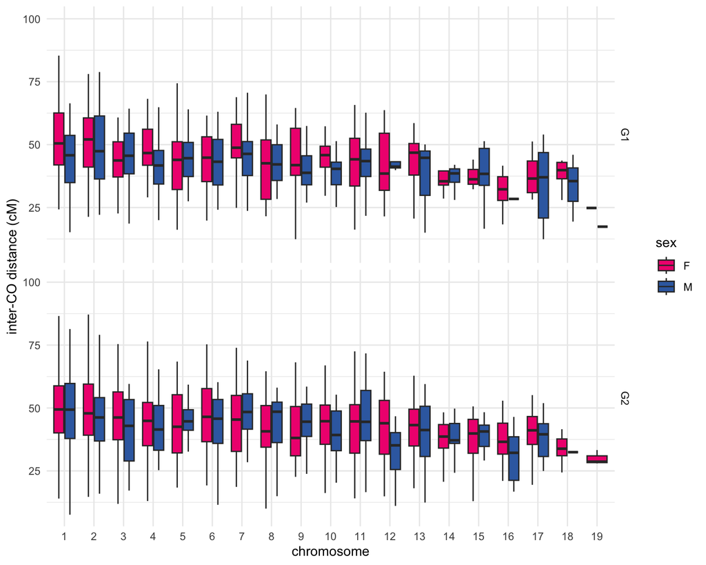

```r
subset(xodist, censor == 0) %>%
    ggplot() +
    geom_boxplot(aes(x = chr, y = inter, fill = sex),
                 outlier.colour = NA) +
    scale_y_continuous("inter-CO distance (cM)") +
    scale_x_discrete("chromosome", label = chrom_labeller) +
    scale_fill_sex() +
    facet_grid(generation ~ .)
```

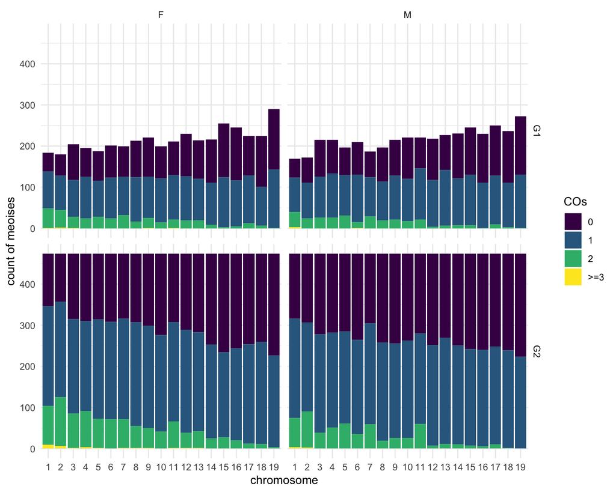

```r
xos_per_chr <- bind_rows( xos_g1, xos_g2 ) %>%
    subset(is_autosome(chr)) %>%
    group_by(funnel, generation, meiosis, sex, chr) %>%
    summarise(n_xo = sum(!is.na(cM))) %>%
    mutate(n_xo_class = cut(n_xo, breaks = c(0,1,2,3,Inf), right = FALSE))

ggplot(xos_per_chr) +
    geom_bar(aes(x = chr, fill = n_xo_class), position = "stack") +
    scale_fill_viridis_d("COs", labels = c("0","1","2",">=3")) +
    scale_x_discrete("chromosome", labels = chrom_labeller) +
    scale_y_continuous("count of meoises") +
    facet_grid(generation ~ sex)
```

Show that total crossovers and number of chromosomes with multiple crossovers are correlated. (These are integer counts, jittered to reduce overplotting.)

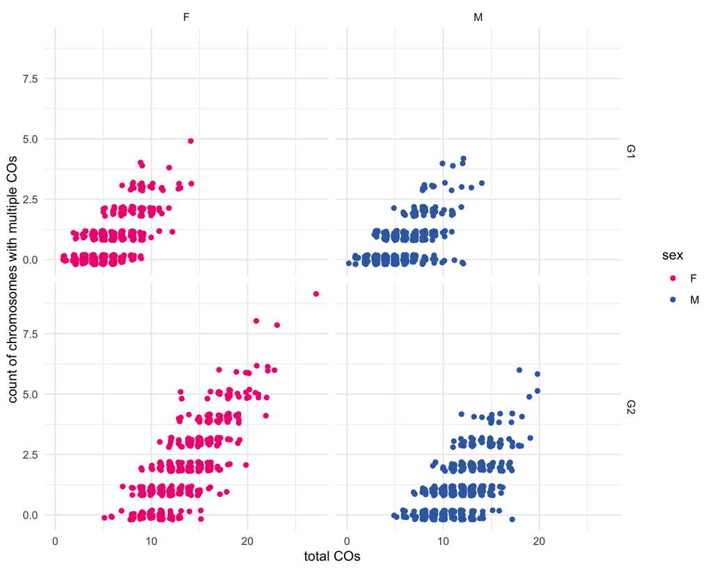

```r
xos_per_chr %>%
    group_by(funnel, generation, meiosis, sex) %>%
    summarise(n_multi_xo = sum(n_xo > 1),
              n_total_xo = sum(n_xo)) %>%
    ggplot() +
    geom_point(aes(x = n_total_xo, y = n_multi_xo, colour = sex),
               position = position_jitter(width = 0.2, height = 0.2)) +
    scale_x_continuous("total COs") +
    scale_y_continuous("count of chromosomes with multiple COs") +
    facet_grid(generation ~ sex) +
    scale_color_sex()
```

# Modelling crossover interference

Following previous work, we will use the Housworth & Stahl (2003) *Am J Hum Genet* 10.1086/376610 model of crossover interference. This models the distribution of inter-crossover distances as a mixture of two processes: a pathway *with* interference following the gamma model; and a pathway *without* interference. The model has two parameters: $\nu$, the strength of interference under the gamma model; and $p$, the fraction of crossovers which occur via the non-interfering pathway. The data required to estimate the parameters for this model are a set of meiotic products, represented as a vector of crossover points (where an empty vector indicates a chromosome transmitted unbroken). The calculation of the likelihood is implemented in Karl Broman’s `xoi` package (https://github.com/kbroman/xoi).

We model group-specific values of $(\nu_i, p_i)$ that are parameterised as shown below. Here $(x_1, \dots x_m)$ are a vector of covariates (which are actually just indicators). The strength of interference ($\nu$) and the proportion of non-interfering crossovers ($p$) are, by construction, restricted to the intervals $(0, \infty)$ and $(0, 1)$, respectively. Transformation to the log and logit scales, respectively, allow for estimation on a numerically-friendly domain.
$$\begin{aligned}
\log(\nu_i) &= \beta_1 x_1 + \beta_2 x_2 + \dots + \beta_m x_m \\
\text{logit}(p_i) &= \alpha_1 x_1 + \alpha_2 x_2 + \dots + \alpha_m x_m
\end{aligned}$$
We estimate $\theta_i = (\alpha_1, \dots, alpha_m; \beta_1, \dots, \beta_m)$ via MCMC as previously described. The covariance matrix is assumed to be diagonal. The proposal distribution is tuned *ad hoc* to ensure adequate mixing.

# Results

We fit a series of models of increasing complexity. These can be split into two broad classes: first, a single value of $(\nu_i, p_i)$ is estimated for each group, representing a global interference process acting equally on all chromosomes; and second, with chromosome-specific values for $(\nu_{ij}, p_{ij})$. We will describe the design matrix for the $\beta$s via `R`-style formula notation. Models are summarized in the table below.

```r
model_formulas <- c(
    "all_sex_gen" = "~ sex + generation",
    "all_sex_gen_full" = "~ 0 + sex:generation"
)
model_escape <- c("_no_escape","")
model_chromwise <- c("_chromwise","")
model_setup <- expand_grid( model_name = names(model_formulas), model_chromwise, model_escape ) %>%
    mutate(prefix = paste0(model_name, model_chromwise, model_escape)) %>%
    mutate(formula = model_formulas[ model_name ],
           escape = ifelse(nchar(model_escape), "no", "yes"),
           chromosome_specific = ifelse(nchar(model_chromwise), "yes","no"))

summarise_model_params <- function(model_name, ...) {

    ff <- paste0("model_fits/", model_name, "/out_A.rds")
    x <- readRDS(ff)
    tibble( n_groups = length(x$data$data),
            n_params = sum(!is.na(x$trace[1,])) )

}

model_setup %>%
    group_by(model_name, formula, escape, chromosome_specific) %>%
    do( summarise_model_params(.$prefix[1]) )
```

```
## # A tibble: 8 × 6
## # Groups:   model_name, formula, escape, chromosome_specific [8]
##   model_name       formula          escape chromosome_specific n_groups n_params
##   <chr>            <chr>            <chr>  <chr>                  <int>    <int>
## 1 all_sex_gen      ~ sex + generat… no     no                         4        3
## 2 all_sex_gen      ~ sex + generat… no     yes                        4       57
## 3 all_sex_gen      ~ sex + generat… yes    no                         4        6
## 4 all_sex_gen      ~ sex + generat… yes    yes                        4      114
## 5 all_sex_gen_full ~ 0 + sex:gener… no     no                         4        4
## 6 all_sex_gen_full ~ 0 + sex:gener… no     yes                        4       76
## 7 all_sex_gen_full ~ 0 + sex:gener… yes    no                         4        8
## 8 all_sex_gen_full ~ 0 + sex:gener… yes    yes                        4      152
```

## Global interference process

### Model: `~ sex + generation`, with escape

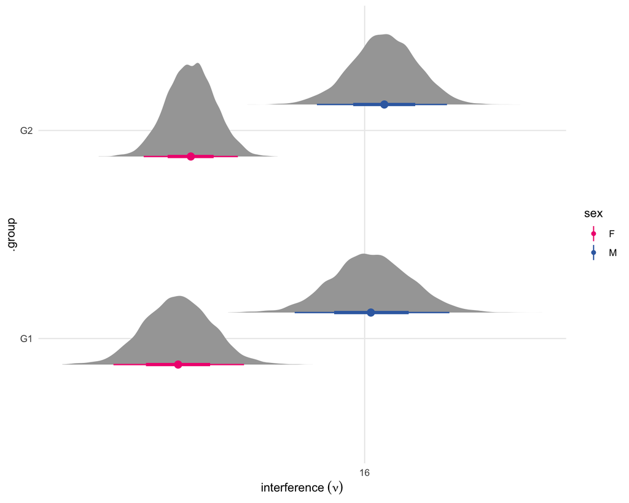

```r
BURNIN <- 10e3
rez <- readRDS("model_fits/all_sex_gen/out_precooked.rds")
plot_stahl_model_estimates(rez$predicted, what = "nu")
```

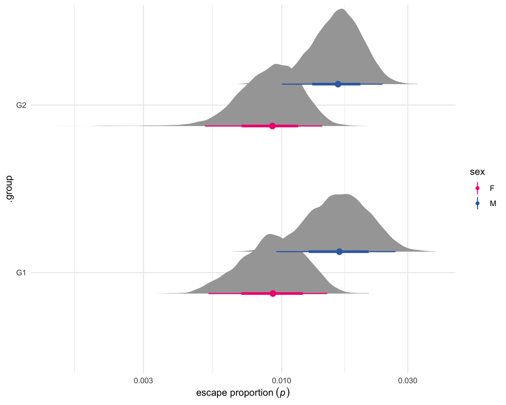

```r
plot_stahl_model_estimates(rez$predicted, what = "p")
```

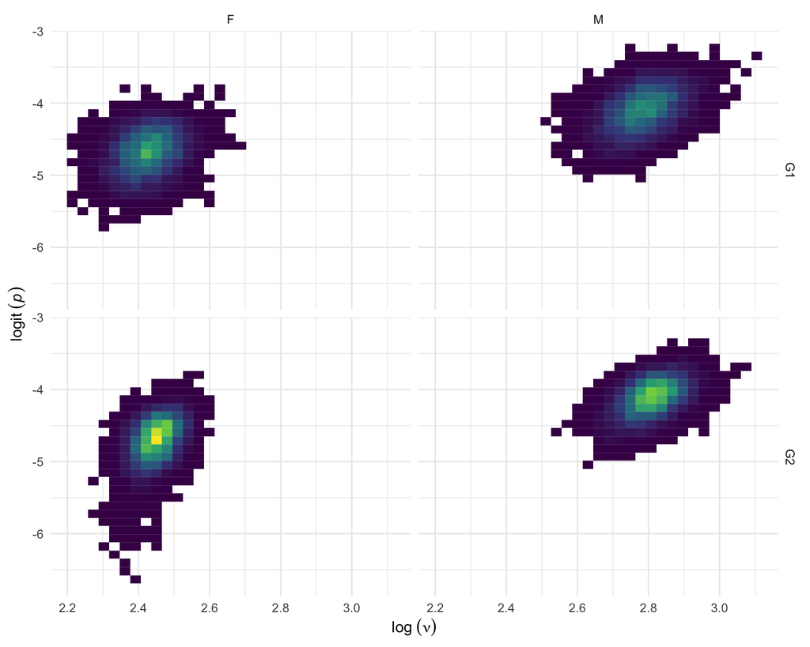

```r
plot_stahl_posterior_correlations(rez$predicted) +
    facet_grid(generation ~ sex)
```

### Model: `~ sex + generation`, without escape

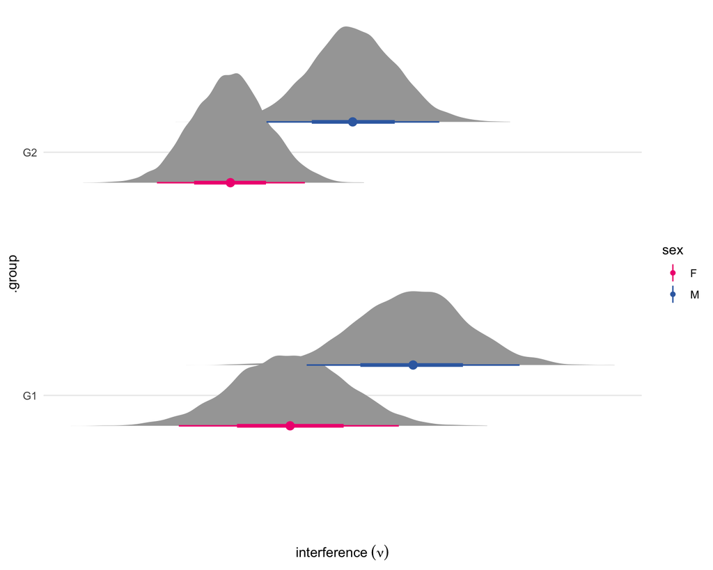

```r
rez <- readRDS("model_fits/all_sex_gen_no_escape/out_precooked.rds")
plot_stahl_model_estimates(rez$predicted, what = "nu")
```

### Model: `~ 0 + sex:generation`, with escape

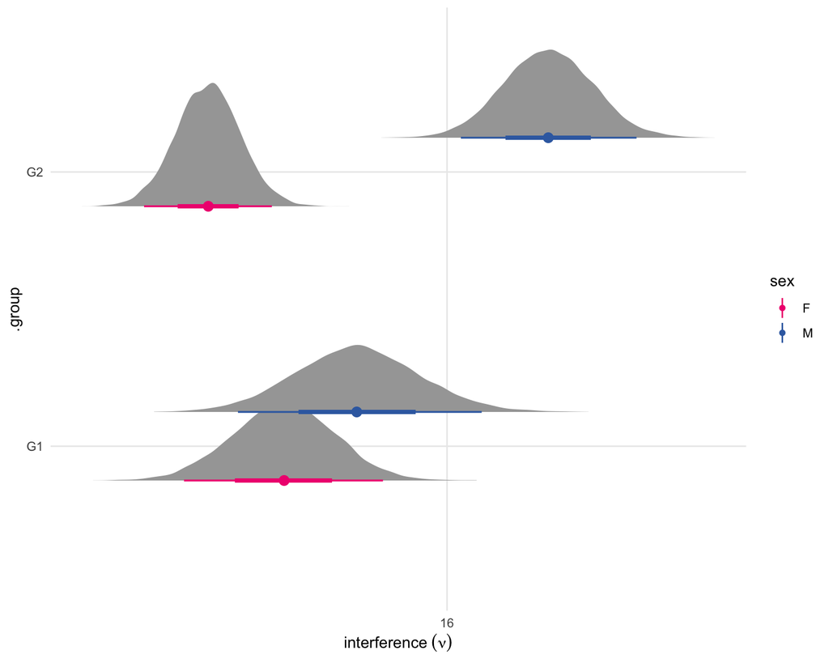

```r
rez <- readRDS("model_fits/all_sex_gen_full/out_precooked.rds")
plot_stahl_model_estimates(rez$predicted, what = "nu")
```

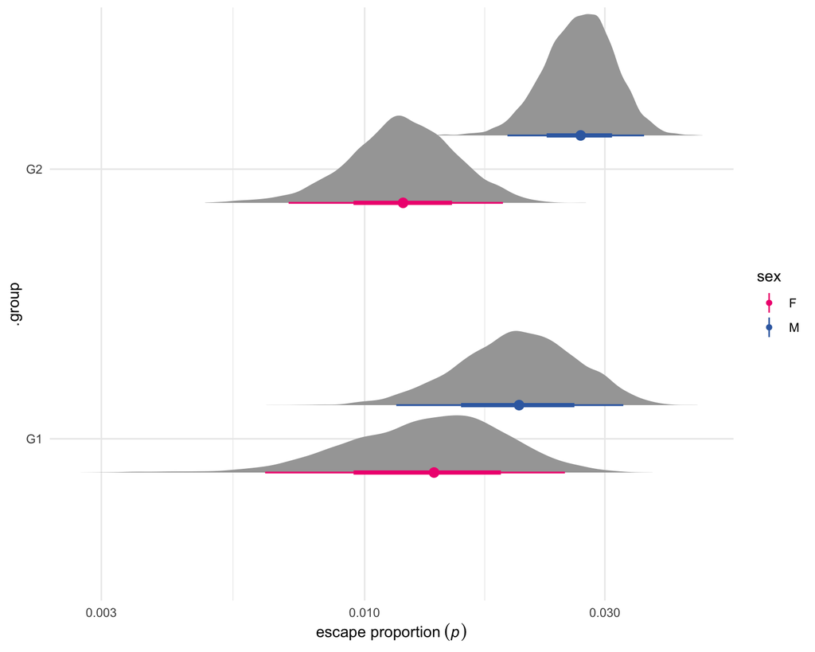

```r
plot_stahl_model_estimates(rez$predicted, what = "p")
```

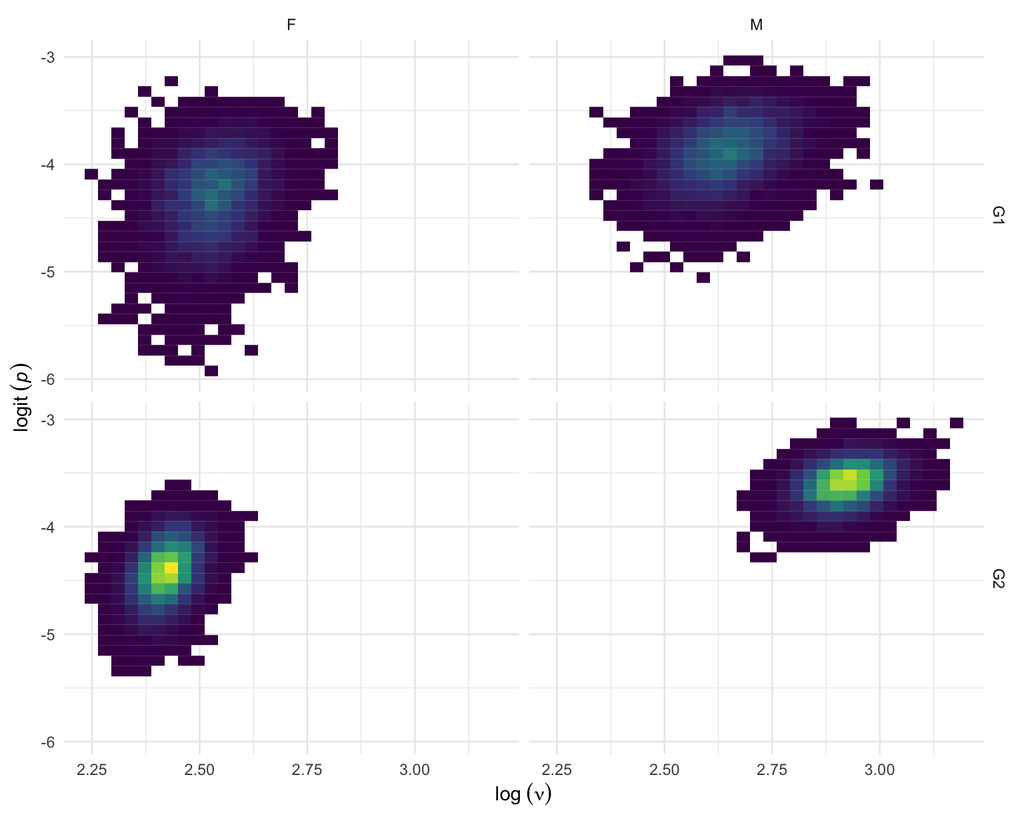

```r
plot_stahl_posterior_correlations(rez$predicted) +
    facet_grid(generation ~ sex)
```

### Model: `~ 0 + sex:generation`, without escape

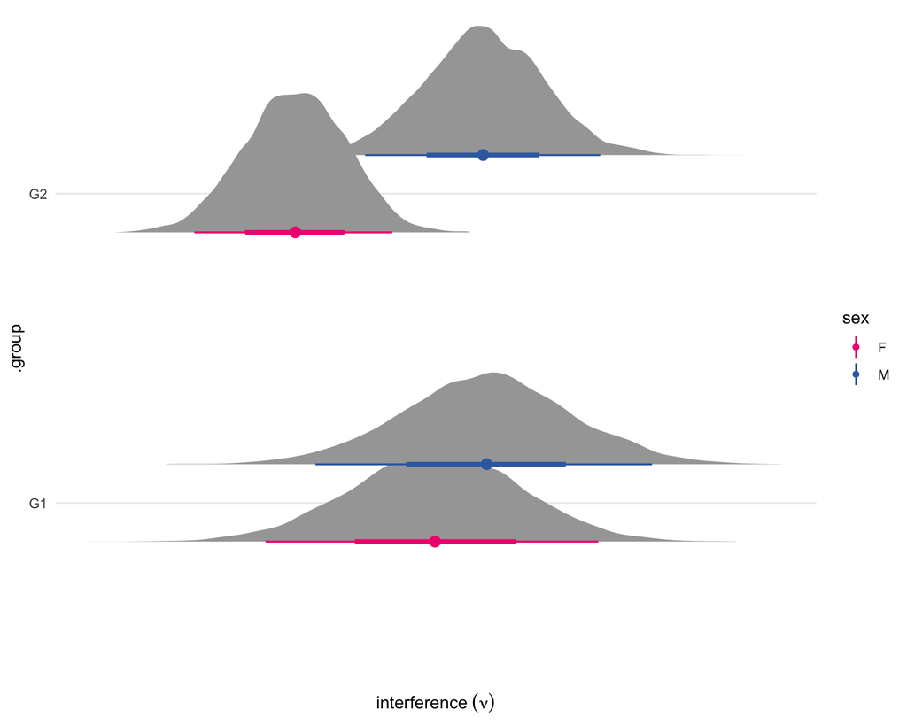

```r
rez <- readRDS("model_fits/all_sex_gen_full_no_escape/out_precooked.rds")
plot_stahl_model_estimates(rez$predicted, what = "nu")
```

## Summary

Assume the full model, allowing for sex- and generation-specific values of $\nu$ and $p$, fits the data best. (How to rigorously assess goodness-of-fit for this class of models is something I have not yet worked out.) Point estimates and $95\%$ HPDIs for the parameters are:

```r
rez <- readRDS("model_fits/all_sex_gen_full/out_precooked.rds")
hpdis <- rez$predicted %>%
    group_by(generation, sex) %>%
    do( calc_hpdis_for_model(., prob = 0.95, transform = TRUE) )
hpdis
```

```
## # A tibble: 8 × 6
## # Groups:   generation, sex [4]
##   generation sex   term  estimate  conf_lo conf_hi
##   <chr>      <chr> <chr>    <dbl>    <dbl>   <dbl>
## 1 G1         F     nu     12.6    10.8     14.5
## 2 G1         F     p       0.0134  0.00673  0.0260
## 3 G1         M     nu     14.0    11.7     16.7
## 4 G1         M     p       0.0201  0.0120   0.0337
## 5 G2         F     nu     11.3    10.2     12.4
## 6 G2         F     p       0.0119  0.00727  0.0190
## 7 G2         M     nu     18.6    16.3     21.1
## 8 G2         M     p       0.0267  0.0195   0.0362
```

Does $\nu$ differ by sex (marginalizing across G1 and G2)? Note that since $\nu$ is estimated on the log scale, linear contrasts, once back-transformed, are interpreted as ratios rather than absolute differences.

```r
rez$coefs_nu %>%
    mutate(term = "delta_nu",
           sex_diff = (`sexM:generationG1` + `sexM:generationG2`)/2 - (`sexF:generationG1` + `sexF:generationG2`)/2) %>%
    do( calc_hpdi_from_vector(.$sex_diff) ) %>%
    mutate_all(exp)
```

```
## # A tibble: 1 × 3
##   estimate conf_lo conf_hi
##      <dbl>   <dbl>   <dbl>
## 1     1.35    1.17    1.57
```

The lower bound for this ratio is $>1$ so **yes**, $\nu$ is significantly higher in males than females.

Now, does $p$ differ by sex? Note that since $p$ is a probability that is estimated on the logit scale, linear contrasts, once back-transformed, are interpreted as odds ratios rather than absolute differences in probability.

```r
rez$coefs_p %>%
    mutate(term = "delta_p",
           sex_diff = (`sexM:generationG1` + `sexM:generationG2`)/2 - (`sexF:generationG1` + `sexF:generationG2`)/2) %>%
    do( calc_hpdi_from_vector(.$sex_diff) ) %>%
    mutate_all(exp)
```

```
## # A tibble: 1 × 3
##   estimate conf_lo conf_hi
##      <dbl>   <dbl>   <dbl>
## 1     1.84    1.10    3.25
```

The lower bound for this ratio is $>1$ so **yes**, $p$ is significantly higher in males than females.

The magnitude of the sex effect seems different in G2 than G1. Recall that the products of G1 meioses are not directly observed but can be partially reconstructed, provided they are transmitted at G2. The difference in effect size between generations suggests that the observable G1 meiotic products may be a nonrandom sample. This needs more thought. However, restricting our attention to the G2 meioses, the sex effect is actually stronger.

```r
rez$coefs_nu %>%
    mutate(term = "dela_nu", sex_diff = `sexM:generationG2` - `sexF:generationG2`) %>%
    do( calc_hpdi_from_vector(.$sex_diff) ) %>%
    mutate_all(exp)
```

```
## # A tibble: 1 × 3
##   estimate conf_lo conf_hi
##      <dbl>   <dbl>   <dbl>
## 1     1.66    1.40    1.95
```

```r
rez$coefs_p %>%
    mutate(term = "delta_p", sex_diff = `sexM:generationG2` - `sexF:generationG2`) %>%
    do( calc_hpdi_from_vector(.$sex_diff) ) %>%
    mutate_all(exp)
```

```
## # A tibble: 1 × 3
##   estimate conf_lo conf_hi
##      <dbl>   <dbl>   <dbl>
## 1     2.16    1.26    4.31
```

## What about the X chromosome?

The above analyses are restricted to the autosomes. What about the X chromsome? Here we limit the analysis to female meioses, since the X chromosome is non-recombining in males, except for the pseuodoautosomal region. Haplotypes for the X are not available for G2 individuals to the analysis is further limited to G2 meioses. (Note that at least the product of the PGM meiosis can be reconstructed trivially, it is transmitted without change [outside the PAR] to the G2:F1 male.)

```r
## make inputs for X chromosome, G2 only
xos_x <- readRDS("xos_inferred/xo_detail_all.rds") %>% subset(chr == "chrX")
x <- tidyr::expand_grid( funnel = unique(funnels$funnel),
                         meiosis = c("Mf","Mm"),
                         chr = factor_chrom( "chrX" ) ) %>%
    mutate(sex = m2s[meiosis])
xos_g2_x <- left_join(x, xos_x)

breaks_x <- subset(xos_g2_x, sex == "F") %>%
    mutate(iid = paste0(funnel, "_", meiosis)) %>%
    split(., .$iid) %>%
    lapply(., xo_intervals_to_breaks)
saveRDS(breaks_x, "xos_inferred/breaks_by_iid_X.rds")
```

There should be ($237$ funnels $\times~2$ G2 female meioses) = $474$ meiotic products.

```r
breaks_x <- readRDS("xos_inferred/breaks_by_iid_X.rds")
length(breaks_x)
```

```
## [1] 474
```

Show estimates of interference parameters, just for the X chromosome at G2.

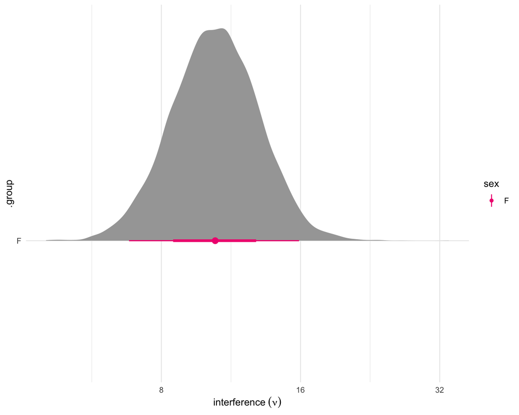

```r
rez <- process_mcmc_result("model_fits/G2_chrX/out", covars = NULL, thin_factor = 5, burnin = 10e3)
plot_stahl_model_estimates(mutate(rez$predicted, sex = "F"), group_by = "sex", what = "nu")
```

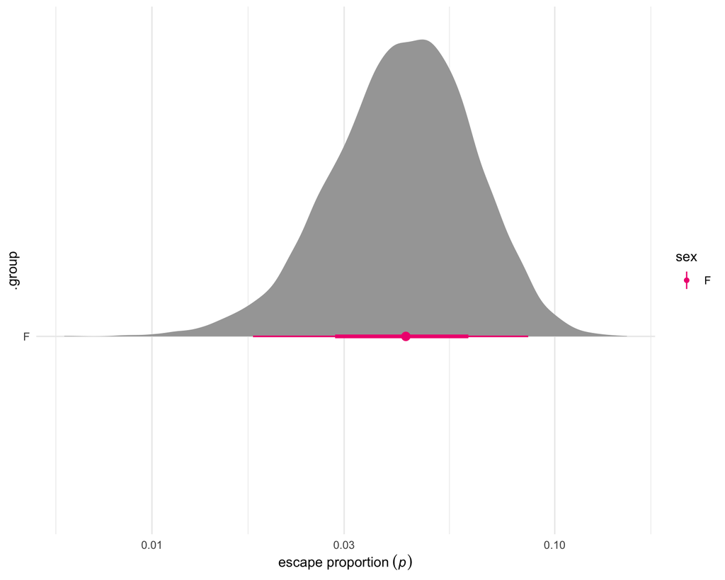

```r
plot_stahl_model_estimates(mutate(rez$predicted, sex = "F"), group_by = "sex", what = "p")
```

```r
hpdis_x <- calc_hpdis_for_model(rez$predicted, transform = TRUE)
```

HPDIs are much wider than for the autosomes since there is much less data. Estimate of $\nu$ is similar to autosomes; $p$ is at upper boundary of the HPDI for the autosomes. Show direct comparison to full model (allowing generation-by-sex interaction) for autosomes.

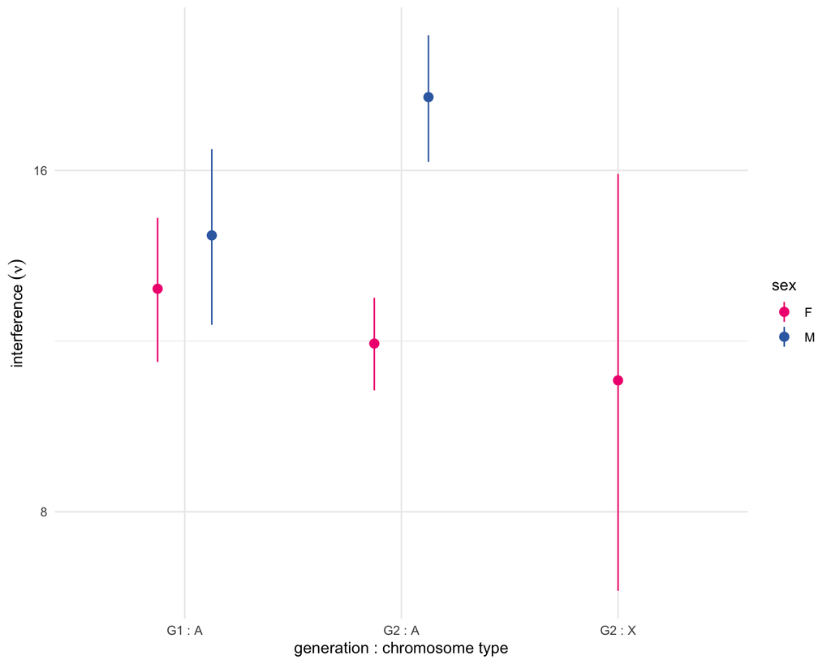

```r
hpdis_both <- bind_rows(
    mutate(hpdis, chrtype = "A"),
    mutate(hpdis_x, generation = "G2", sex = "F", chrtype = "X"),
)

subset(hpdis_both, term == "nu") %>%
    ggplot() +
    geom_pointrange(aes(x = interaction(generation, chrtype, sep = " : "), y = estimate, ymin = conf_lo, ymax = conf_hi, colour = sex),
                    position = position_dodge(width = 0.5)) +
    scale_colour_sex() +
    scale_x_discrete("generation : chromosome type") +
    scale_y_interference_nu()
```

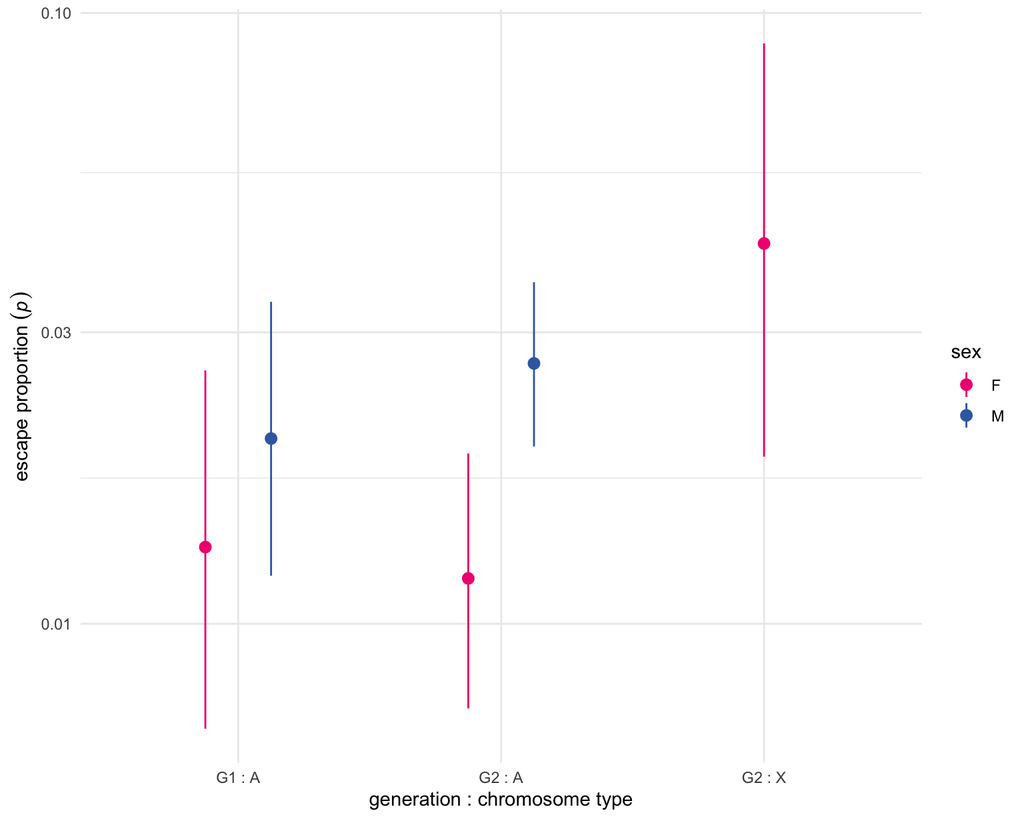

```r
subset(hpdis_both, term == "p") %>%
    ggplot() +
    geom_pointrange(aes(x = interaction(generation, chrtype, sep = " : "), y = estimate, ymin = conf_lo, ymax = conf_hi, colour = sex),
                    position = position_dodge(width = 0.5)) +
    scale_colour_sex() +
    scale_x_discrete("generation : chromosome type") +
    scale_y_interference_p()
```

It appears that the escape proportion is higher on the X chromosome than the autosomes – with the caveat that $p_\text{autosomes}$ and $p_{X}$ are not estimated simultaneously.

## Genetic effects at G1

The G1 generation is an incomplete diallel between the founder strains. To the extent that the partially-observed meiotic products of G1 are a reliable substrate for inference, we can use them to estimate genetic effects on crossover interference.

```r
## annotate and save just the G1 meioses
meioses_g1 <- left_join(meioses, funnels) %>%
    subset(generation == "G1") %>%
    mutate(parents = assign_G1_parents(order, meiosis)) %>%
    mutate(mat_ss = xrenamer[ substr(parents, 1, 1) ], pat_ss = xrenamer[ substr(parents, 2, 2) ]) %>%
    mutate(parents_ss = paste0(substr(pat_ss, 1, 1), substr(mat_ss, 1, 1)))
saveRDS(meioses_g1, "xos_inferred/meioses_g1.rds")
```

```r
meioses_g1 <- readRDS("xos_inferred/meioses_g1.rds")
```

First count the number of meioses for each pair of parental strains.

```r
with(meioses_g1, table( substr(parents, 1, 1),
                        substr(parents, 2, 2),
                        sex,
                        dnn = c("mat","pat","sex") ))
```

```
## , , sex = F
##
##    pat
## mat  A  B  C  D  E  F  G  H
##   A  0  9  3  4 27 11 12  3
##   B  5  0  3  2 17 10 10 17
##   C  9  3  0  4  5  6 10 13
##   D  5  3  3  0  8 14  8 16
##   E 16 29  7 19  0  0  0  9
##   F  4  5 10 15 10  0 10  8
##   G  8  2 19  5  3  7  0  4
##   H  7  3 11  2 12  1  8  0
##
## , , sex = M
##
##    pat
## mat  A  B  C  D  E  F  G  H
##   A  0  5  6 11  7 14 14  5
##   B 10  0  4  4  6 11 15 16
##   C 10  8  0  7 13  5 11 16
##   D  9  6  7  0  8  8 16 10
##   E  2  5  6  9  0  0  0  5
##   F  3 10 11 17  5  0 21  8
##   G 12 13  0 13  2  7  0  3
##   H  6  6 27  4  7  6  4  0
```

Double-check that the total number of meiosis matches expectations ($237$ funnels $~\times~4$ meioses at G1 $~=~948$ meioses).

```r
nrow(meioses_g1)
```

```
## [1] 948
```

These are probably too sparse attempt to estimate interference parameters at the strain level. However, aggregating strains by subspecies (assigning all classical laboratory strains as *M. m. domesticus* with all applicable caveats acknowledged), the problem may be tractable.

```r
with(meioses_g1, table( mat_ss,
                        pat_ss,
                        sex,
                        dnn = c("mat","pat","sex") ))
```

```
## , , sex = F
##
##      pat
## mat   cas dom mus
##   cas   0  52  10
##   dom  42 274  48
##   mus   7  41   0
##
## , , sex = M
##
##      pat
## mat   cas dom mus
##   cas   0  54  21
##   dom  44 245  60
##   mus   7  43   0
```

Show the results of fitting a full model (separate values of $\nu, p$ for every sex-genotype combination) to meiotic products from G1.

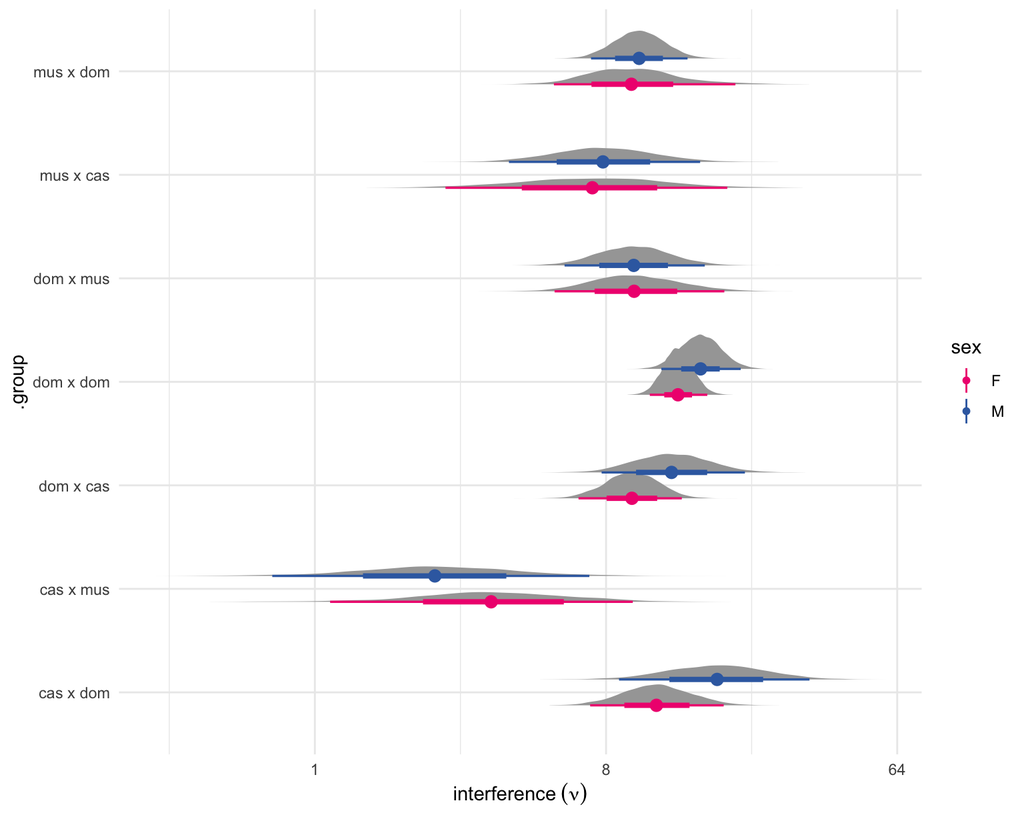

```r
rez <- readRDS("model_fits/G1_sex_ss/out_precooked.rds")

genotype_labeller <- function(f) {
    ss <- c("d" = "dom", "m" = "mus", "c" = "cas")
    return( paste0(ss[ substr(f,1,1) ], " x ", ss[ substr(f,2,2) ]) )
}

plot_stahl_model_estimates(rez$predicted, what = "nu", group_by = "parents_ss") +
    scale_x_discrete(label = genotype_labeller)
```

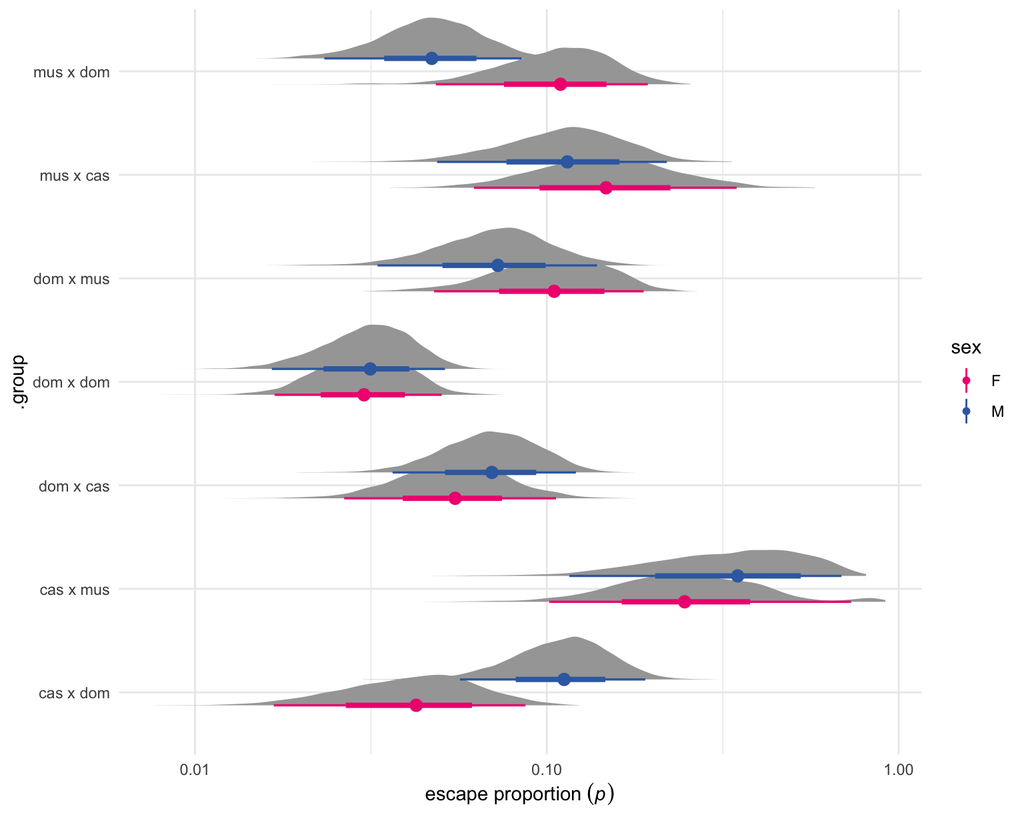

```r
plot_stahl_model_estimates(rez$predicted, what = "p", group_by = "parents_ss") +
    scale_x_discrete(label = genotype_labeller)
```

It looks like there is variation between genotypes, but less so between sexes. Construct contrasts between male and female for each genotype.

```r
nu <- rez$coefs_nu %>% select(-.iter, -.chain) %>% as.matrix()
pp <- rez$coefs_nu %>% select(-.iter, -.chain) %>% as.matrix()

sex_contrasts <- list(
    "cd" = c(rep(0, 0), -1,1, rep(0,12)),
    "cm" = c(rep(0, 2), -1,1, rep(0,10)),
    "dc" = c(rep(0, 4), -1,1, rep(0, 8)),
    "dd" = c(rep(0, 6), -1,1, rep(0, 6)),
    "dm" = c(rep(0, 8), -1,1, rep(0, 4)),
    "mc" = c(rep(0,10), -1,1, rep(0, 2)),
    "md" = c(rep(0,12), -1,1, rep(0, 0))
)

g1_sex_effs <- bind_rows(
    lapply(sex_contrasts, function(f) calc_hpdi_from_vector(nu %*% f)) %>%
        bind_rows(.id = "genotype") %>%
        mutate(term = "nu"),
    lapply(sex_contrasts, function(f) calc_hpdi_from_vector(pp %*% f)) %>%
        bind_rows(.id = "genotype") %>%
        mutate(term = "p")
)
```

Below are $95\%$ HPDIs for male-female comparisons for $\nu,p$ within genotype. For $\nu$ the result is a ratio; for $p$, an odds ratio. Dashed grey line indicates the null.

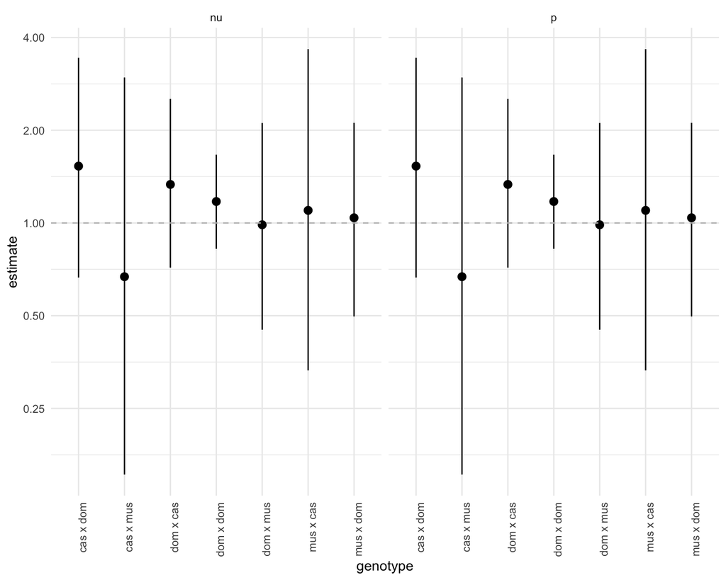

```r
mutate_if(g1_sex_effs, is.numeric, exp) %>%
    ggplot() +
    geom_pointrange(aes(x = genotype, y = estimate, ymin = conf_lo, ymax = conf_hi)) +
    geom_hline(yintercept = 1, colour = "grey", lty = "dashed") +
    scale_y_continuous(trans = "log2") +
    scale_x_discrete(label = genotype_labeller) +
    facet_grid(. ~ term) +
    theme(axis.text.x = element_text(angle = 90, hjust = 1))
```

We do not detect a difference between sexes, within genotypes. The power of this analysis is limited by small sample size and by whatever additional uncertainty is added by the incomplete observation of G1 meiotic products via their transmission at G2.

**More to follow.**

```r
# stop early
knitr::knit_exit()
```